# Risk Factor Analysis

## Outcome Variable

**Outcome Variable:** ever_stunted

## Predictor Variables

**Intervention Variable:** perdiar6

**Adjustment Set:**

unadjusted

## Stratifying Variables

The analysis was stratified on these variable(s):

- agecat
- studyid
- country

## Data Summary

| agecat | studyid | country | perdiar6 | ever_stunted | n_cell | n |
| --- | --- | --- | --- | --- | --- | --- |
| 0-24 months (no birth st.) | ki0047075b-MAL-ED | BANGLADESH | 0% | 0 | 35 | 217 |
| 0-24 months (no birth st.) | ki0047075b-MAL-ED | BANGLADESH | 0% | 1 | 37 | 217 |
| 0-24 months (no birth st.) | ki0047075b-MAL-ED | BANGLADESH | (0%, 5%] | 0 | 41 | 217 |
| 0-24 months (no birth st.) | ki0047075b-MAL-ED | BANGLADESH | (0%, 5%] | 1 | 44 | 217 |
| 0-24 months (no birth st.) | ki0047075b-MAL-ED | BANGLADESH | >5% | 0 | 27 | 217 |
| 0-24 months (no birth st.) | ki0047075b-MAL-ED | BANGLADESH | >5% | 1 | 33 | 217 |
| 0-24 months (no birth st.) | ki0047075b-MAL-ED | BRAZIL | 0% | 0 | 156 | 202 |
| 0-24 months (no birth st.) | ki0047075b-MAL-ED | BRAZIL | 0% | 1 | 30 | 202 |
| 0-24 months (no birth st.) | ki0047075b-MAL-ED | BRAZIL | (0%, 5%] | 0 | 12 | 202 |
| 0-24 months (no birth st.) | ki0047075b-MAL-ED | BRAZIL | (0%, 5%] | 1 | 2 | 202 |
| 0-24 months (no birth st.) | ki0047075b-MAL-ED | BRAZIL | >5% | 0 | 2 | 202 |
| 0-24 months (no birth st.) | ki0047075b-MAL-ED | BRAZIL | >5% | 1 | 0 | 202 |
| 0-24 months (no birth st.) | ki0047075b-MAL-ED | INDIA | 0% | 0 | 23 | 210 |
| 0-24 months (no birth st.) | ki0047075b-MAL-ED | INDIA | 0% | 1 | 26 | 210 |
| 0-24 months (no birth st.) | ki0047075b-MAL-ED | INDIA | (0%, 5%] | 0 | 53 | 210 |
| 0-24 months (no birth st.) | ki0047075b-MAL-ED | INDIA | (0%, 5%] | 1 | 53 | 210 |
| 0-24 months (no birth st.) | ki0047075b-MAL-ED | INDIA | >5% | 0 | 23 | 210 |
| 0-24 months (no birth st.) | ki0047075b-MAL-ED | INDIA | >5% | 1 | 32 | 210 |
| 0-24 months (no birth st.) | ki0047075b-MAL-ED | NEPAL | 0% | 0 | 53 | 211 |
| 0-24 months (no birth st.) | ki0047075b-MAL-ED | NEPAL | 0% | 1 | 20 | 211 |
| 0-24 months (no birth st.) | ki0047075b-MAL-ED | NEPAL | (0%, 5%] | 0 | 54 | 211 |
| 0-24 months (no birth st.) | ki0047075b-MAL-ED | NEPAL | (0%, 5%] | 1 | 14 | 211 |
| 0-24 months (no birth st.) | ki0047075b-MAL-ED | NEPAL | >5% | 0 | 49 | 211 |
| 0-24 months (no birth st.) | ki0047075b-MAL-ED | NEPAL | >5% | 1 | 21 | 211 |
| 0-24 months (no birth st.) | ki0047075b-MAL-ED | PERU | 0% | 0 | 37 | 266 |
| 0-24 months (no birth st.) | ki0047075b-MAL-ED | PERU | 0% | 1 | 40 | 266 |
| 0-24 months (no birth st.) | ki0047075b-MAL-ED | PERU | (0%, 5%] | 0 | 29 | 266 |
| 0-24 months (no birth st.) | ki0047075b-MAL-ED | PERU | (0%, 5%] | 1 | 51 | 266 |
| 0-24 months (no birth st.) | ki0047075b-MAL-ED | PERU | >5% | 0 | 49 | 266 |
| 0-24 months (no birth st.) | ki0047075b-MAL-ED | PERU | >5% | 1 | 60 | 266 |

[output cut: 204 more lines]

The following strata were considered:

- agecat: 0-24 months (no birth st.), studyid: ki0047075b-MAL-ED, country: BANGLADESH
- agecat: 0-24 months (no birth st.), studyid: ki0047075b-MAL-ED, country: BRAZIL
- agecat: 0-24 months (no birth st.), studyid: ki0047075b-MAL-ED, country: INDIA
- agecat: 0-24 months (no birth st.), studyid: ki0047075b-MAL-ED, country: NEPAL
- agecat: 0-24 months (no birth st.), studyid: ki0047075b-MAL-ED, country: PERU
- agecat: 0-24 months (no birth st.), studyid: ki0047075b-MAL-ED, country: SOUTH AFRICA
- agecat: 0-24 months (no birth st.), studyid: ki0047075b-MAL-ED, country: TANZANIA, UNITED REPUBLIC OF
- agecat: 0-24 months (no birth st.), studyid: ki1000109-EE, country: PAKISTAN
- agecat: 0-24 months (no birth st.), studyid: ki1017093-NIH-Birth, country: BANGLADESH
- agecat: 0-24 months (no birth st.), studyid: ki1017093b-PROVIDE, country: BANGLADESH
- agecat: 0-24 months (no birth st.), studyid: ki1017093c-NIH-Crypto, country: BANGLADESH
- agecat: 0-24 months (no birth st.), studyid: ki1114097-CMIN, country: BANGLADESH
- agecat: 0-24 months (no birth st.), studyid: ki1114097-CONTENT, country: PERU
- agecat: 0-6 months (no birth st.), studyid: ki0047075b-MAL-ED, country: BANGLADESH
- agecat: 0-6 months (no birth st.), studyid: ki0047075b-MAL-ED, country: BRAZIL
- agecat: 0-6 months (no birth st.), studyid: ki0047075b-MAL-ED, country: INDIA
- agecat: 0-6 months (no birth st.), studyid: ki0047075b-MAL-ED, country: NEPAL
- agecat: 0-6 months (no birth st.), studyid: ki0047075b-MAL-ED, country: PERU
- agecat: 0-6 months (no birth st.), studyid: ki0047075b-MAL-ED, country: SOUTH AFRICA
- agecat: 0-6 months (no birth st.), studyid: ki0047075b-MAL-ED, country: TANZANIA, UNITED REPUBLIC OF
- agecat: 0-6 months (no birth st.), studyid: ki1000109-EE, country: PAKISTAN
- agecat: 0-6 months (no birth st.), studyid: ki1017093-NIH-Birth, country: BANGLADESH
- agecat: 0-6 months (no birth st.), studyid: ki1017093b-PROVIDE, country: BANGLADESH
- agecat: 0-6 months (no birth st.), studyid: ki1017093c-NIH-Crypto, country: BANGLADESH
- agecat: 0-6 months (no birth st.), studyid: ki1114097-CMIN, country: BANGLADESH
- agecat: 0-6 months (no birth st.), studyid: ki1114097-CONTENT, country: PERU
- agecat: 6-24 months, studyid: ki0047075b-MAL-ED, country: BANGLADESH
- agecat: 6-24 months, studyid: ki0047075b-MAL-ED, country: BRAZIL
- agecat: 6-24 months, studyid: ki0047075b-MAL-ED, country: INDIA
- agecat: 6-24 months, studyid: ki0047075b-MAL-ED, country: NEPAL
- agecat: 6-24 months, studyid: ki0047075b-MAL-ED, country: PERU
- agecat: 6-24 months, studyid: ki0047075b-MAL-ED, country: SOUTH AFRICA
- agecat: 6-24 months, studyid: ki0047075b-MAL-ED, country: TANZANIA, UNITED REPUBLIC OF
- agecat: 6-24 months, studyid: ki1000109-EE, country: PAKISTAN
- agecat: 6-24 months, studyid: ki1017093-NIH-Birth, country: BANGLADESH
- agecat: 6-24 months, studyid: ki1017093b-PROVIDE, country: BANGLADESH
- agecat: 6-24 months, studyid: ki1017093c-NIH-Crypto, country: BANGLADESH
- agecat: 6-24 months, studyid: ki1114097-CMIN, country: BANGLADESH
- agecat: 6-24 months, studyid: ki1114097-CONTENT, country: PERU

### Dropped Strata

Some strata were dropped due to rare outcomes:

- agecat: 0-24 months (no birth st.), studyid: ki0047075b-MAL-ED, country: BRAZIL
- agecat: 0-24 months (no birth st.), studyid: ki0047075b-MAL-ED, country: SOUTH AFRICA
- agecat: 0-24 months (no birth st.), studyid: ki1000109-EE, country: PAKISTAN
- agecat: 0-6 months (no birth st.), studyid: ki0047075b-MAL-ED, country: BRAZIL
- agecat: 0-6 months (no birth st.), studyid: ki0047075b-MAL-ED, country: NEPAL
- agecat: 0-6 months (no birth st.), studyid: ki0047075b-MAL-ED, country: SOUTH AFRICA
- agecat: 0-6 months (no birth st.), studyid: ki1000109-EE, country: PAKISTAN
- agecat: 0-6 months (no birth st.), studyid: ki1114097-CONTENT, country: PERU
- agecat: 6-24 months, studyid: ki0047075b-MAL-ED, country: BRAZIL
- agecat: 6-24 months, studyid: ki0047075b-MAL-ED, country: SOUTH AFRICA
- agecat: 6-24 months, studyid: ki1000109-EE, country: PAKISTAN
- agecat: 6-24 months, studyid: ki1114097-CONTENT, country: PERU

## Methods Detail

We’re interested in the causal parameters $E[Y_a]$ for all values of $a \in \mathcal{A}$. These parameters represent the mean outcome if, possibly contrary to fact, we intervened to set all units to have $A=a$. Under the randomization and positivity assumptions, these are identified by the statistical parameters $\psi_a=E_W[E_{Y|A,W}(Y|A=a,W)]$. In addition, we’re interested in the mean of $Y$, $E[Y]$ under no intervention (the observed mean). We will estimate these parameters by using SuperLearner to fit the relevant likelihood factors – $E_{Y|A,W}(Y|A=a,W)$ and $p(A=a|W)$, and then updating our likelihood fit using a joint TMLE.

For unadjusted analyses ($W=\{\}$), initial likelihoods were estimated using Lrnr_glm to estimate the simple $E(Y|A)$ and Lrnr_mean to estimate $p(A)$. For adjusted analyses, a small library containing Lrnr_glmnet, Lrnr_xgboost, and Lrnr_mean was used.

Having estimated these parameters, we will then use the delta method to estimate relative risks and attributable risks relative to a prespecified baseline level of $A$.

# Results Detail

## Results Plots

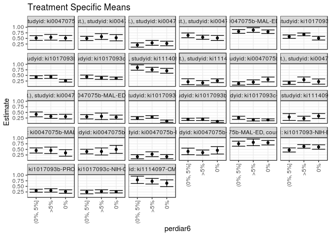

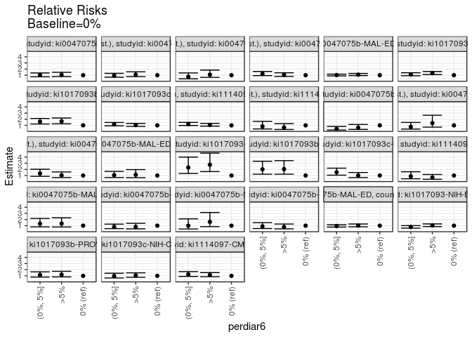

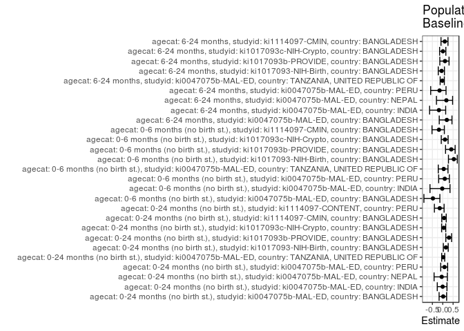

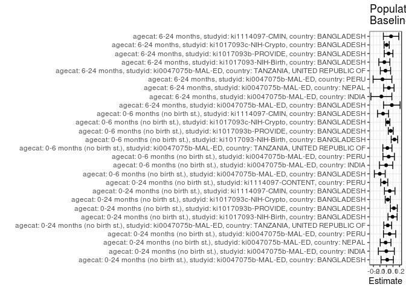

## Results Table

### Parameter: TSM

| agecat | studyid | country | intervention_level | baseline_level | estimate | ci_lower | ci_upper |
| --- | --- | --- | --- | --- | --- | --- | --- |
| 0-24 months (no birth st.) | ki0047075b-MAL-ED | BANGLADESH | 0% | NA | 0.5138889 | 0.3981745 | 0.6296032 |
| 0-24 months (no birth st.) | ki0047075b-MAL-ED | BANGLADESH | (0%, 5%] | NA | 0.5176471 | 0.4111737 | 0.6241204 |
| 0-24 months (no birth st.) | ki0047075b-MAL-ED | BANGLADESH | >5% | NA | 0.5500000 | 0.4238280 | 0.6761720 |
| 0-24 months (no birth st.) | ki0047075b-MAL-ED | INDIA | 0% | NA | 0.5306122 | 0.3905436 | 0.6706809 |
| 0-24 months (no birth st.) | ki0047075b-MAL-ED | INDIA | (0%, 5%] | NA | 0.5000000 | 0.4045883 | 0.5954117 |
| 0-24 months (no birth st.) | ki0047075b-MAL-ED | INDIA | >5% | NA | 0.5818182 | 0.4511471 | 0.7124893 |
| 0-24 months (no birth st.) | ki0047075b-MAL-ED | NEPAL | 0% | NA | 0.2739726 | 0.1714196 | 0.3765256 |
| 0-24 months (no birth st.) | ki0047075b-MAL-ED | NEPAL | (0%, 5%] | NA | 0.2058824 | 0.1095489 | 0.3022158 |
| 0-24 months (no birth st.) | ki0047075b-MAL-ED | NEPAL | >5% | NA | 0.3000000 | 0.1923931 | 0.4076069 |
| 0-24 months (no birth st.) | ki0047075b-MAL-ED | PERU | 0% | NA | 0.5194805 | 0.4076756 | 0.6312854 |
| 0-24 months (no birth st.) | ki0047075b-MAL-ED | PERU | (0%, 5%] | NA | 0.6375000 | 0.5319605 | 0.7430395 |
| 0-24 months (no birth st.) | ki0047075b-MAL-ED | PERU | >5% | NA | 0.5504587 | 0.4568966 | 0.6440208 |
| 0-24 months (no birth st.) | ki0047075b-MAL-ED | TANZANIA, UNITED REPUBLIC OF | 0% | NA | 0.7978723 | 0.7165036 | 0.8792411 |
| 0-24 months (no birth st.) | ki0047075b-MAL-ED | TANZANIA, UNITED REPUBLIC OF | (0%, 5%] | NA | 0.8117647 | 0.7284737 | 0.8950557 |
| 0-24 months (no birth st.) | ki0047075b-MAL-ED | TANZANIA, UNITED REPUBLIC OF | >5% | NA | 0.8750000 | 0.7722762 | 0.9777238 |
| 0-24 months (no birth st.) | ki1017093-NIH-Birth | BANGLADESH | 0% | NA | 0.5106383 | 0.4280494 | 0.5932272 |
| 0-24 months (no birth st.) | ki1017093-NIH-Birth | BANGLADESH | (0%, 5%] | NA | 0.5786164 | 0.5017926 | 0.6554401 |
| 0-24 months (no birth st.) | ki1017093-NIH-Birth | BANGLADESH | >5% | NA | 0.6798246 | 0.6192089 | 0.7404402 |
| 0-24 months (no birth st.) | ki1017093b-PROVIDE | BANGLADESH | 0% | NA | 0.2623762 | 0.2016613 | 0.3230912 |
| 0-24 months (no birth st.) | ki1017093b-PROVIDE | BANGLADESH | (0%, 5%] | NA | 0.4243697 | 0.3615282 | 0.4872113 |
| 0-24 months (no birth st.) | ki1017093b-PROVIDE | BANGLADESH | >5% | NA | 0.4352332 | 0.3652315 | 0.5052348 |
| 0-24 months (no birth st.) | ki1017093c-NIH-Crypto | BANGLADESH | 0% | NA | 0.3738019 | 0.3201623 | 0.4274415 |
| 0-24 months (no birth st.) | ki1017093c-NIH-Crypto | BANGLADESH | (0%, 5%] | NA | 0.4370861 | 0.3579095 | 0.5162627 |
| 0-24 months (no birth st.) | ki1017093c-NIH-Crypto | BANGLADESH | >5% | NA | 0.3915344 | 0.3218953 | 0.4611735 |
| 0-24 months (no birth st.) | ki1114097-CMIN | BANGLADESH | 0% | NA | 0.7058824 | 0.5972606 | 0.8145041 |
| 0-24 months (no birth st.) | ki1114097-CMIN | BANGLADESH | (0%, 5%] | NA | 0.8529412 | 0.7335396 | 0.9723428 |
| 0-24 months (no birth st.) | ki1114097-CMIN | BANGLADESH | >5% | NA | 0.7575758 | 0.6538770 | 0.8612745 |
| 0-24 months (no birth st.) | ki1114097-CONTENT | PERU | 0% | NA | 0.2616822 | 0.1781854 | 0.3451791 |
| 0-24 months (no birth st.) | ki1114097-CONTENT | PERU | (0%, 5%] | NA | 0.2162162 | 0.0832337 | 0.3491987 |
| 0-24 months (no birth st.) | ki1114097-CONTENT | PERU | >5% | NA | 0.1698113 | 0.0684699 | 0.2711527 |

[output cut: 51 more lines]

### Parameter: E(Y)

| agecat | studyid | country | intervention_level | baseline_level | estimate | ci_lower | ci_upper |
| --- | --- | --- | --- | --- | --- | --- | --- |
| 0-24 months (no birth st.) | ki0047075b-MAL-ED | BANGLADESH | NA | NA | 0.5253456 | 0.4587520 | 0.5919392 |
| 0-24 months (no birth st.) | ki0047075b-MAL-ED | INDIA | NA | NA | 0.5285714 | 0.4608954 | 0.5962474 |
| 0-24 months (no birth st.) | ki0047075b-MAL-ED | NEPAL | NA | NA | 0.2606635 | 0.2012891 | 0.3200380 |
| 0-24 months (no birth st.) | ki0047075b-MAL-ED | PERU | NA | NA | 0.5676692 | 0.5080232 | 0.6273151 |
| 0-24 months (no birth st.) | ki0047075b-MAL-ED | TANZANIA, UNITED REPUBLIC OF | NA | NA | 0.8173516 | 0.7660617 | 0.8686415 |
| 0-24 months (no birth st.) | ki1017093-NIH-Birth | BANGLADESH | NA | NA | 0.6041667 | 0.5624147 | 0.6459187 |
| 0-24 months (no birth st.) | ki1017093b-PROVIDE | BANGLADESH | NA | NA | 0.3759874 | 0.3382238 | 0.4137509 |
| 0-24 months (no birth st.) | ki1017093c-NIH-Crypto | BANGLADESH | NA | NA | 0.3935681 | 0.3560687 | 0.4310676 |
| 0-24 months (no birth st.) | ki1114097-CMIN | BANGLADESH | NA | NA | 0.7559524 | 0.6908084 | 0.8210964 |
| 0-24 months (no birth st.) | ki1114097-CONTENT | PERU | NA | NA | 0.2284264 | 0.1696529 | 0.2871999 |
| 0-6 months (no birth st.) | ki0047075b-MAL-ED | BANGLADESH | NA | NA | 0.2165899 | 0.1616567 | 0.2715231 |
| 0-6 months (no birth st.) | ki0047075b-MAL-ED | INDIA | NA | NA | 0.2190476 | 0.1629743 | 0.2751210 |
| 0-6 months (no birth st.) | ki0047075b-MAL-ED | PERU | NA | NA | 0.3458647 | 0.2885967 | 0.4031327 |
| 0-6 months (no birth st.) | ki0047075b-MAL-ED | TANZANIA, UNITED REPUBLIC OF | NA | NA | 0.3013699 | 0.2404592 | 0.3622805 |
| 0-6 months (no birth st.) | ki1017093-NIH-Birth | BANGLADESH | NA | NA | 0.2291667 | 0.1932828 | 0.2650505 |
| 0-6 months (no birth st.) | ki1017093b-PROVIDE | BANGLADESH | NA | NA | 0.1595577 | 0.1310079 | 0.1881074 |
| 0-6 months (no birth st.) | ki1017093c-NIH-Crypto | BANGLADESH | NA | NA | 0.1898928 | 0.1597870 | 0.2199986 |
| 0-6 months (no birth st.) | ki1114097-CMIN | BANGLADESH | NA | NA | 0.2857143 | 0.2171983 | 0.3542303 |
| 6-24 months | ki0047075b-MAL-ED | BANGLADESH | NA | NA | 0.4240506 | 0.3467471 | 0.5013542 |
| 6-24 months | ki0047075b-MAL-ED | INDIA | NA | NA | 0.4220779 | 0.3438191 | 0.5003367 |
| 6-24 months | ki0047075b-MAL-ED | NEPAL | NA | NA | 0.2113402 | 0.1537425 | 0.2689379 |
| 6-24 months | ki0047075b-MAL-ED | PERU | NA | NA | 0.3959732 | 0.3171819 | 0.4747644 |
| 6-24 months | ki0047075b-MAL-ED | TANZANIA, UNITED REPUBLIC OF | NA | NA | 0.7847222 | 0.7173567 | 0.8520877 |
| 6-24 months | ki1017093-NIH-Birth | BANGLADESH | NA | NA | 0.5739130 | 0.5216565 | 0.6261696 |
| 6-24 months | ki1017093b-PROVIDE | BANGLADESH | NA | NA | 0.3004386 | 0.2583143 | 0.3425629 |
| 6-24 months | ki1017093c-NIH-Crypto | BANGLADESH | NA | NA | 0.2628458 | 0.2244546 | 0.3012371 |
| 6-24 months | ki1114097-CMIN | BANGLADESH | NA | NA | 0.7117117 | 0.6270636 | 0.7963598 |

### Parameter: RR

| agecat | studyid | country | intervention_level | baseline_level | estimate | ci_lower | ci_upper |
| --- | --- | --- | --- | --- | --- | --- | --- |
| 0-24 months (no birth st.) | ki0047075b-MAL-ED | BANGLADESH | 0% | 0% | 1.0000000 | 1.0000000 | 1.0000000 |
| 0-24 months (no birth st.) | ki0047075b-MAL-ED | BANGLADESH | (0%, 5%] | 0% | 1.0073132 | 0.7425318 | 1.3665138 |
| 0-24 months (no birth st.) | ki0047075b-MAL-ED | BANGLADESH | >5% | 0% | 1.0702703 | 0.7760506 | 1.4760358 |
| 0-24 months (no birth st.) | ki0047075b-MAL-ED | INDIA | 0% | 0% | 1.0000000 | 1.0000000 | 1.0000000 |
| 0-24 months (no birth st.) | ki0047075b-MAL-ED | INDIA | (0%, 5%] | 0% | 0.9423077 | 0.6803497 | 1.3051284 |
| 0-24 months (no birth st.) | ki0047075b-MAL-ED | INDIA | >5% | 0% | 1.0965035 | 0.7753328 | 1.5507146 |
| 0-24 months (no birth st.) | ki0047075b-MAL-ED | NEPAL | 0% | 0% | 1.0000000 | 1.0000000 | 1.0000000 |
| 0-24 months (no birth st.) | ki0047075b-MAL-ED | NEPAL | (0%, 5%] | 0% | 0.7514706 | 0.4127427 | 1.3681841 |
| 0-24 months (no birth st.) | ki0047075b-MAL-ED | NEPAL | >5% | 0% | 1.0950000 | 0.6520210 | 1.8389362 |
| 0-24 months (no birth st.) | ki0047075b-MAL-ED | PERU | 0% | 0% | 1.0000000 | 1.0000000 | 1.0000000 |
| 0-24 months (no birth st.) | ki0047075b-MAL-ED | PERU | (0%, 5%] | 0% | 1.2271875 | 0.9353767 | 1.6100350 |
| 0-24 months (no birth st.) | ki0047075b-MAL-ED | PERU | >5% | 0% | 1.0596330 | 0.8054736 | 1.3939901 |
| 0-24 months (no birth st.) | ki0047075b-MAL-ED | TANZANIA, UNITED REPUBLIC OF | 0% | 0% | 1.0000000 | 1.0000000 | 1.0000000 |
| 0-24 months (no birth st.) | ki0047075b-MAL-ED | TANZANIA, UNITED REPUBLIC OF | (0%, 5%] | 0% | 1.0174118 | 0.8803783 | 1.1757749 |
| 0-24 months (no birth st.) | ki0047075b-MAL-ED | TANZANIA, UNITED REPUBLIC OF | >5% | 0% | 1.0966667 | 0.9387248 | 1.2811824 |
| 0-24 months (no birth st.) | ki1017093-NIH-Birth | BANGLADESH | 0% | 0% | 1.0000000 | 1.0000000 | 1.0000000 |
| 0-24 months (no birth st.) | ki1017093-NIH-Birth | BANGLADESH | (0%, 5%] | 0% | 1.1331237 | 0.9191782 | 1.3968666 |
| 0-24 months (no birth st.) | ki1017093-NIH-Birth | BANGLADESH | >5% | 0% | 1.3313231 | 1.1068158 | 1.6013695 |
| 0-24 months (no birth st.) | ki1017093b-PROVIDE | BANGLADESH | 0% | 0% | 1.0000000 | 1.0000000 | 1.0000000 |
| 0-24 months (no birth st.) | ki1017093b-PROVIDE | BANGLADESH | (0%, 5%] | 0% | 1.6174092 | 1.2288717 | 2.1287923 |
| 0-24 months (no birth st.) | ki1017093b-PROVIDE | BANGLADESH | >5% | 0% | 1.6588132 | 1.2514379 | 2.1987996 |
| 0-24 months (no birth st.) | ki1017093c-NIH-Crypto | BANGLADESH | 0% | 0% | 1.0000000 | 1.0000000 | 1.0000000 |
| 0-24 months (no birth st.) | ki1017093c-NIH-Crypto | BANGLADESH | (0%, 5%] | 0% | 1.1692987 | 0.9280291 | 1.4732937 |
| 0-24 months (no birth st.) | ki1017093c-NIH-Crypto | BANGLADESH | >5% | 0% | 1.0474382 | 0.8334484 | 1.3163703 |
| 0-24 months (no birth st.) | ki1114097-CMIN | BANGLADESH | 0% | 0% | 1.0000000 | 1.0000000 | 1.0000000 |
| 0-24 months (no birth st.) | ki1114097-CMIN | BANGLADESH | (0%, 5%] | 0% | 1.2083333 | 0.9813886 | 1.4877587 |
| 0-24 months (no birth st.) | ki1114097-CMIN | BANGLADESH | >5% | 0% | 1.0732323 | 0.8734742 | 1.3186739 |
| 0-24 months (no birth st.) | ki1114097-CONTENT | PERU | 0% | 0% | 1.0000000 | 1.0000000 | 1.0000000 |
| 0-24 months (no birth st.) | ki1114097-CONTENT | PERU | (0%, 5%] | 0% | 0.8262548 | 0.4132357 | 1.6520764 |
| 0-24 months (no birth st.) | ki1114097-CONTENT | PERU | >5% | 0% | 0.6489218 | 0.3298309 | 1.2767136 |

[output cut: 51 more lines]

### Parameter: PAR

| agecat | studyid | country | intervention_level | baseline_level | estimate | ci_lower | ci_upper |
| --- | --- | --- | --- | --- | --- | --- | --- |
| 0-24 months (no birth st.) | ki0047075b-MAL-ED | BANGLADESH | 0% | NA | 0.0114567 | -0.0830902 | 0.1060036 |
| 0-24 months (no birth st.) | ki0047075b-MAL-ED | INDIA | 0% | NA | -0.0020408 | -0.1246933 | 0.1206117 |
| 0-24 months (no birth st.) | ki0047075b-MAL-ED | NEPAL | 0% | NA | -0.0133091 | -0.0955599 | 0.0689417 |
| 0-24 months (no birth st.) | ki0047075b-MAL-ED | PERU | 0% | NA | 0.0481887 | -0.0457312 | 0.1421085 |
| 0-24 months (no birth st.) | ki0047075b-MAL-ED | TANZANIA, UNITED REPUBLIC OF | 0% | NA | 0.0194793 | -0.0402523 | 0.0792108 |
| 0-24 months (no birth st.) | ki1017093-NIH-Birth | BANGLADESH | 0% | NA | 0.0935284 | 0.0233774 | 0.1636794 |
| 0-24 months (no birth st.) | ki1017093b-PROVIDE | BANGLADESH | 0% | NA | 0.1136111 | 0.0610785 | 0.1661438 |
| 0-24 months (no birth st.) | ki1017093c-NIH-Crypto | BANGLADESH | 0% | NA | 0.0197662 | -0.0192873 | 0.0588197 |
| 0-24 months (no birth st.) | ki1114097-CMIN | BANGLADESH | 0% | NA | 0.0500700 | -0.0304974 | 0.1306374 |
| 0-24 months (no birth st.) | ki1114097-CONTENT | PERU | 0% | NA | -0.0332558 | -0.0866666 | 0.0201549 |
| 0-6 months (no birth st.) | ki0047075b-MAL-ED | BANGLADESH | 0% | NA | -0.1028546 | -0.1861475 | -0.0195617 |
| 0-6 months (no birth st.) | ki0047075b-MAL-ED | INDIA | 0% | NA | -0.0054422 | -0.1077077 | 0.0968233 |
| 0-6 months (no birth st.) | ki0047075b-MAL-ED | PERU | 0% | NA | 0.0341763 | -0.0541595 | 0.1225122 |
| 0-6 months (no birth st.) | ki0047075b-MAL-ED | TANZANIA, UNITED REPUBLIC OF | 0% | NA | 0.0141358 | -0.0558632 | 0.0841348 |
| 0-6 months (no birth st.) | ki1017093-NIH-Birth | BANGLADESH | 0% | NA | 0.1227837 | 0.0728172 | 0.1727501 |
| 0-6 months (no birth st.) | ki1017093b-PROVIDE | BANGLADESH | 0% | NA | 0.0654983 | 0.0280515 | 0.1029450 |
| 0-6 months (no birth st.) | ki1017093c-NIH-Crypto | BANGLADESH | 0% | NA | 0.0205637 | -0.0107068 | 0.0518342 |
| 0-6 months (no birth st.) | ki1114097-CMIN | BANGLADESH | 0% | NA | -0.0525210 | -0.1368856 | 0.0318436 |
| 6-24 months | ki0047075b-MAL-ED | BANGLADESH | 0% | NA | 0.0825872 | -0.0445924 | 0.2097669 |
| 6-24 months | ki0047075b-MAL-ED | INDIA | 0% | NA | -0.0779221 | -0.2385211 | 0.0826769 |
| 6-24 months | ki0047075b-MAL-ED | NEPAL | 0% | NA | 0.0367370 | -0.0433482 | 0.1168223 |
| 6-24 months | ki0047075b-MAL-ED | PERU | 0% | NA | -0.0611697 | -0.2052077 | 0.0828683 |
| 6-24 months | ki0047075b-MAL-ED | TANZANIA, UNITED REPUBLIC OF | 0% | NA | -0.0152778 | -0.0943813 | 0.0638257 |
| 6-24 months | ki1017093-NIH-Birth | BANGLADESH | 0% | NA | -0.0324699 | -0.1172195 | 0.0522797 |
| 6-24 months | ki1017093b-PROVIDE | BANGLADESH | 0% | NA | 0.0327221 | -0.0336637 | 0.0991078 |
| 6-24 months | ki1017093c-NIH-Crypto | BANGLADESH | 0% | NA | 0.0026832 | -0.0367783 | 0.0421448 |
| 6-24 months | ki1114097-CMIN | BANGLADESH | 0% | NA | 0.0706861 | -0.0474877 | 0.1888598 |

### Parameter: PAF

| agecat | studyid | country | intervention_level | baseline_level | estimate | ci_lower | ci_upper |
| --- | --- | --- | --- | --- | --- | --- | --- |
| 0-24 months (no birth st.) | ki0047075b-MAL-ED | BANGLADESH | 0% | NA | 0.0218080 | -0.1758122 | 0.1862139 |
| 0-24 months (no birth st.) | ki0047075b-MAL-ED | INDIA | 0% | NA | -0.0038610 | -0.2649176 | 0.2033182 |
| 0-24 months (no birth st.) | ki0047075b-MAL-ED | NEPAL | 0% | NA | -0.0510585 | -0.4190114 | 0.2214833 |
| 0-24 months (no birth st.) | ki0047075b-MAL-ED | PERU | 0% | NA | 0.0848886 | -0.0968632 | 0.2365239 |
| 0-24 months (no birth st.) | ki0047075b-MAL-ED | TANZANIA, UNITED REPUBLIC OF | 0% | NA | 0.0238322 | -0.0521798 | 0.0943528 |
| 0-24 months (no birth st.) | ki1017093-NIH-Birth | BANGLADESH | 0% | NA | 0.1548056 | 0.0294489 | 0.2639711 |
| 0-24 months (no birth st.) | ki1017093b-PROVIDE | BANGLADESH | 0% | NA | 0.3021674 | 0.1481204 | 0.4283578 |
| 0-24 months (no birth st.) | ki1017093c-NIH-Crypto | BANGLADESH | 0% | NA | 0.0502231 | -0.0544049 | 0.1444690 |
| 0-24 months (no birth st.) | ki1114097-CMIN | BANGLADESH | 0% | NA | 0.0662344 | -0.0474806 | 0.1676044 |
| 0-24 months (no birth st.) | ki1114097-CONTENT | PERU | 0% | NA | -0.1455867 | -0.4037931 | 0.0651266 |
| 0-6 months (no birth st.) | ki0047075b-MAL-ED | BANGLADESH | 0% | NA | -0.4748818 | -0.9097091 | -0.1390616 |
| 0-6 months (no birth st.) | ki0047075b-MAL-ED | INDIA | 0% | NA | -0.0248447 | -0.6161868 | 0.3501329 |
| 0-6 months (no birth st.) | ki0047075b-MAL-ED | PERU | 0% | NA | 0.0988142 | -0.1964269 | 0.3211990 |
| 0-6 months (no birth st.) | ki0047075b-MAL-ED | TANZANIA, UNITED REPUBLIC OF | 0% | NA | 0.0469052 | -0.2160687 | 0.2530112 |
| 0-6 months (no birth st.) | ki1017093-NIH-Birth | BANGLADESH | 0% | NA | 0.5357834 | 0.2764639 | 0.7021612 |
| 0-6 months (no birth st.) | ki1017093b-PROVIDE | BANGLADESH | 0% | NA | 0.4104989 | 0.1356635 | 0.5979442 |
| 0-6 months (no birth st.) | ki1017093c-NIH-Crypto | BANGLADESH | 0% | NA | 0.1082913 | -0.0719424 | 0.2582208 |
| 0-6 months (no birth st.) | ki1114097-CMIN | BANGLADESH | 0% | NA | -0.1838235 | -0.5189632 | 0.0773719 |
| 6-24 months | ki0047075b-MAL-ED | BANGLADESH | 0% | NA | 0.1947579 | -0.1692082 | 0.4454240 |
| 6-24 months | ki0047075b-MAL-ED | INDIA | 0% | NA | -0.1846154 | -0.6348712 | 0.1416366 |
| 6-24 months | ki0047075b-MAL-ED | NEPAL | 0% | NA | 0.1738289 | -0.3043634 | 0.4767112 |
| 6-24 months | ki0047075b-MAL-ED | PERU | 0% | NA | -0.1544794 | -0.5829813 | 0.1580300 |
| 6-24 months | ki0047075b-MAL-ED | TANZANIA, UNITED REPUBLIC OF | 0% | NA | -0.0194690 | -0.1255240 | 0.0765927 |
| 6-24 months | ki1017093-NIH-Birth | BANGLADESH | 0% | NA | -0.0565764 | -0.2152543 | 0.0813826 |
| 6-24 months | ki1017093b-PROVIDE | BANGLADESH | 0% | NA | 0.1089143 | -0.1416982 | 0.3045152 |
| 6-24 months | ki1017093c-NIH-Crypto | BANGLADESH | 0% | NA | 0.0102084 | -0.1519051 | 0.1495069 |
| 6-24 months | ki1114097-CMIN | BANGLADESH | 0% | NA | 0.0993184 | -0.0847491 | 0.2521521 |